# Biostat M280 Homework 2

1. Instead of summarising the conditional distribution with a boxplot, you could use a frequency polygon. What do you need to consider when using cut_width() vs cut_number()? How does that impact a visualisation of the 2d distribution of carat and price?

   The function cut_width() divides x into bins of width. By default, boxplots look roughly the same regardless of how many observations there are, so it’s difficult to tell that each boxplot summarises a different number of points. The function cut_number() displays approximately the same number of points in each bin.

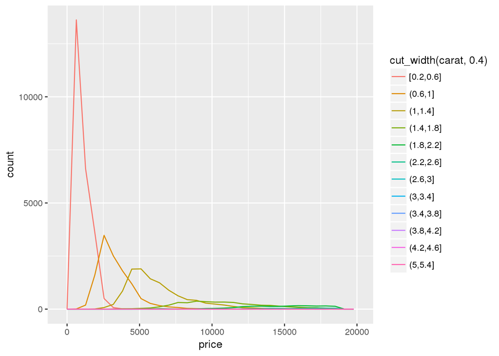

   ```r
   ggplot(data = diamonds, aes(x = price, colour = cut_width(carat, 0.4))) +
     geom_freqpoly()
   ```

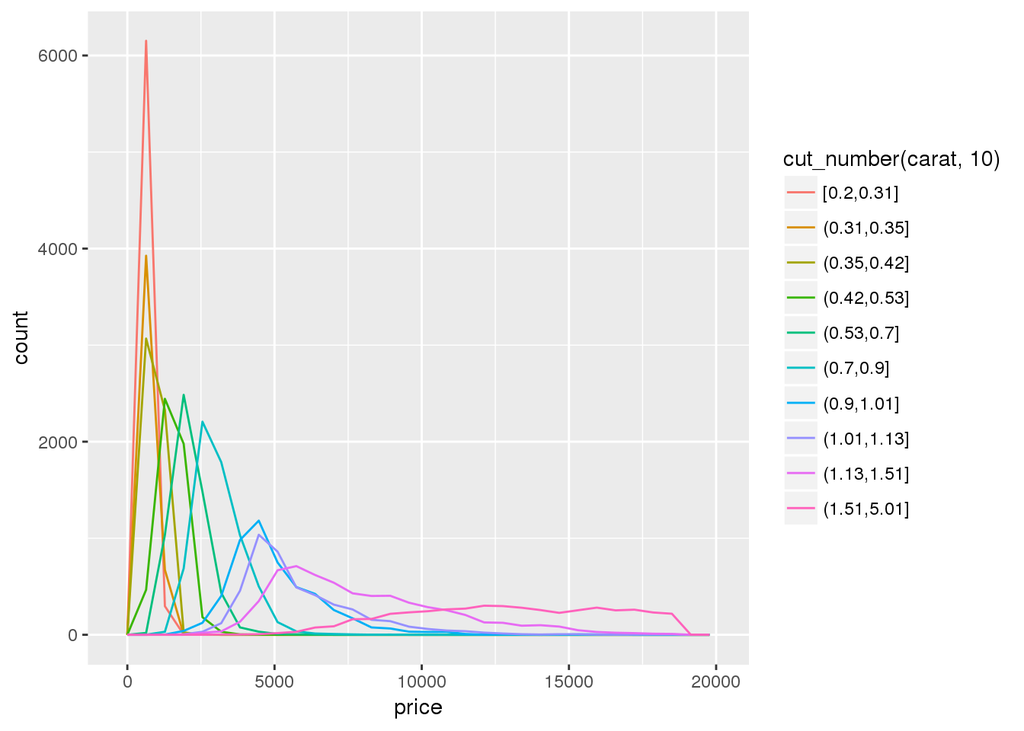

   ```r
   ggplot(data = diamonds, aes(x = price, colour = cut_number(carat, 10))) +
     geom_freqpoly()
   ```

2. Visualise the distribution of carat, partitioned by price.

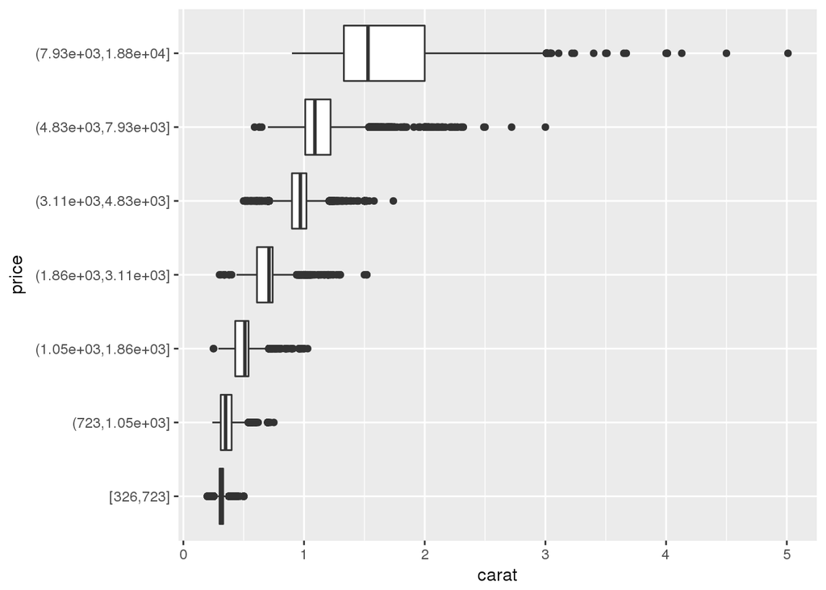

   ```r
   ggplot(diamonds, aes(x = cut_number(price, 7), y = carat)) +
     geom_boxplot() +
     coord_flip() +
     xlab("price")
   ```

3. How does the price distribution of very large diamonds compare to small diamonds. Is it as you expect, or does it surprise you?